# Case Study 1

#### Question 1.

```r
trans_prod<-left_join(transaction,product,by=c("prod_cat_code","prod_subcat_code" = "prod_sub_cat_code"))
Consumer_Final=left_join(trans_prod,customer,by="cust_id")
```

#### Question 2(a).

```r
sapply(Consumer_Final, class)
```

```
##   transaction_id          cust_id        tran_date prod_subcat_code
##        "numeric"        "integer"         "factor"        "integer"
##    prod_cat_code              Qty             Rate              Tax
##        "integer"        "integer"        "integer"        "numeric"
##        total_amt       Store_type         prod_cat      prod_subcat
##        "numeric"         "factor"         "factor"         "factor"
##              DOB           Gender        city_code
##         "factor"         "factor"        "integer"
```

#### Question 2(b).

```r
Top10<-head(Consumer_Final,10)
Bottom10<-tail(Consumer_Final,10)
Top_Bottom10<-rbind(Top10,Bottom10)
Top_Bottom10
```

```
##       transaction_id cust_id  tran_date prod_subcat_code prod_cat_code Qty
## 1        80712190438  270351 28-02-2014                1             1  -5
## 2        29258453508  270384 27-02-2014                5             3  -5
## 3        51750724947  273420 24-02-2014                6             5  -2
## 4        93274880719  271509 24-02-2014               11             6  -3
## 5        51750724947  273420 23-02-2014                6             5  -2
## 6        97439039119  272357 23-02-2014                8             3  -2
## 7        45649838090  273667 22-02-2014               11             6  -1
## 8        22643667930  271489 22-02-2014               12             6  -1
## 9        79792372943  275108 22-02-2014                3             1  -3
## 10       50076728598  269014 21-02-2014                8             3  -4
## 23044    49882891062  271982 25-01-2011               10             5   4
## 23045    14787475597  273982 25-01-2011                4             3   5
## 23046    50691119572  273031 25-01-2011                6             5   1
## 23047    40893803228  272049 25-01-2011               11             6   3
```

[output cut: 48 more lines]

#### Question 2(c).

```r
Five_number_summary<-summary(Consumer_Final)
Five_number_summary
```

```
##  transaction_id         cust_id            tran_date     prod_subcat_code
##  Min.   :3.269e+06   Min.   :266783   13-07-2011:   35   Min.   : 1.000
##  1st Qu.:2.494e+10   1st Qu.:268935   21-12-2013:   33   1st Qu.: 3.000
##  Median :5.009e+10   Median :270980   22-11-2011:   33   Median : 5.000
##  Mean   :5.007e+10   Mean   :271022   23-10-2011:   33   Mean   : 6.149
##  3rd Qu.:7.533e+10   3rd Qu.:273114   25-09-2011:   33   3rd Qu.:10.000
##  Max.   :9.999e+10   Max.   :275265   25-08-2012:   32   Max.   :12.000
##                                       (Other)   :22854
##  prod_cat_code        Qty              Rate              Tax
##  Min.   :1.000   Min.   :-5.000   Min.   :-1499.0   Min.   :  7.35
##  1st Qu.:2.000   1st Qu.: 1.000   1st Qu.:  312.0   1st Qu.: 98.28
##  Median :4.000   Median : 3.000   Median :  710.0   Median :199.08
##  Mean   :3.764   Mean   : 2.432   Mean   :  636.4   Mean   :248.67
##  3rd Qu.:5.000   3rd Qu.: 4.000   3rd Qu.: 1109.0   3rd Qu.:365.71
##  Max.   :6.000   Max.   : 5.000   Max.   : 1500.0   Max.   :787.50
##
##    total_amt                Store_type               prod_cat
##  Min.   :-8270.9   e-Shop        :9311   Bags            :1998
##  1st Qu.:  762.5   Flagship store:4577   Books           :6069
##  Median : 1754.7   MBR           :4661   Clothing        :2960
##  Mean   : 2107.3   TeleShop      :4504   Electronics     :4898
##  3rd Qu.: 3569.2                         Footwear        :2999
##  Max.   : 8287.5                         Home and kitchen:4129
##
##   prod_subcat            DOB        Gender      city_code
##  Women  : 3048   17-09-1982:   32    :    9   Min.   : 1.000
##  Mens   : 2912   27-12-1988:   32   F:11233   1st Qu.: 3.000
##  Kids   : 1997   25-02-1974:   27   M:11811   Median : 5.000
##  Tools  : 1062   20-03-1972:   25             Mean   : 5.483
##  Fiction: 1043   09-06-1970:   24             3rd Qu.: 8.000
##  Kitchen: 1037   18-11-1991:   24             Max.   :10.000
##  (Other):11954   (Other)   :22889             NA's   :8
```

#### Question 2(d).

```r
Frequency1<-Consumer_Final%>%group_by(prod_cat_code)%>%summarise(Total=n())%>%arrange(desc(Total))
Frequency2<-Consumer_Final%>%group_by(prod_subcat_code)%>%summarise(Total=n())%>%arrange(desc(Total))
Frequency3<-Consumer_Final%>%group_by(Store_type)%>%summarise(Total=n())%>%arrange(desc(Total))
Frequency4<-Consumer_Final%>%group_by(prod_cat)%>%summarise(Total=n())%>%arrange(desc(Total))
Frequency5<-Consumer_Final%>%group_by(prod_subcat)%>%summarise(Total=n())%>%arrange(desc(Total))
Frequency6<-Consumer_Final%>%group_by(Gender)%>%summarise(Total=n())%>%arrange(desc(Total))
Frequency7<-Consumer_Final%>%group_by(city_code)%>%summarise(Total=n())%>%arrange(desc(Total))
Frequency1
```

```
## # A tibble: 6 x 2
##   prod_cat_code Total
##           <int> <int>
## 1             5  6069
## 2             3  4898
## 3             6  4129
## 4             2  2999
## 5             1  2960
## 6             4  1998
```

```r
Frequency2
```

```
## # A tibble: 12 x 2
##    prod_subcat_code Total
##               <int> <int>
##  1                4  4002
##  2                3  3067
##  3               10  2993
##  4                1  2950
##  5               11  2058
##  6               12  2029
##  7                7  1043
##  8                2  1007
##  9                6   989
## 10                9   985
## 11                8   972
## 12                5   958
```

```r
Frequency3
```

```
## # A tibble: 4 x 2
##   Store_type     Total
##   <fct>          <int>
## 1 e-Shop          9311
## 2 MBR             4661
## 3 Flagship store  4577
## 4 TeleShop        4504
```

```r
Frequency4
```

```
## # A tibble: 6 x 2
##   prod_cat         Total
##   <fct>            <int>
## 1 Books             6069
## 2 Electronics       4898
## 3 Home and kitchen  4129
## 4 Footwear          2999
## 5 Clothing          2960
## 6 Bags              1998
```

```r
Frequency5
```

```
## # A tibble: 18 x 2
##    prod_subcat         Total
##    <fct>               <int>
##  1 Women                3048
##  2 Mens                 2912
##  3 Kids                 1997
##  4 Tools                1062
##  5 Fiction              1043
##  6 Kitchen              1037
##  7 Children             1035
##  8 Comics               1031
##  9 Mobiles              1031
## 10 Bath                 1023
## 11 Furnishing           1007
## 12 Non-Fiction          1004
## 13 DIY                   989
## 14 Cameras               985
## 15 Personal Appliances   972
## 16 Academic              967
## 17 Computers             958
## 18 Audio and video       952
```

```r
Frequency6
```

```
## # A tibble: 3 x 2
##   Gender Total
##   <fct>  <int>
## 1 M      11811
## 2 F      11233
## 3 ""         9
```

```r
Frequency7
```

```
## # A tibble: 11 x 2
##    city_code Total
##        <int> <int>
##  1         4  2422
##  2         3  2411
##  3         5  2360
##  4         7  2356
##  5        10  2333
##  6         8  2330
##  7         2  2270
##  8         1  2258
##  9         9  2178
## 10         6  2127
## 11        NA     8
```

The first table shows that prod_cat_code 5 has the highest frequency. The second table shows that prod_subcat_code 4 has the highest frequency. The third table shows that e-Shop has the highest frequency. The fourth table shows that Books has the highest frequency. The fifth table shows that Women has the highest frequency. The sixth table shows that male has the highest frequency. The seventh table shows that city_code 4 has the highest frequency.

#### Question 3.

The following charts represents the above frequency tables.

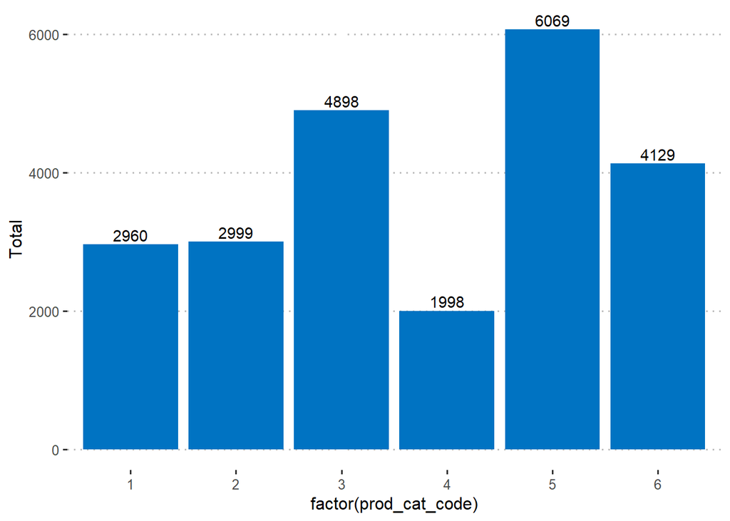

```r
ggplot(Frequency1,aes(x=factor(prod_cat_code),y=Total))+ geom_bar(fill="#0073C2FF",stat = "identity")+geom_text(aes(label=Total),vjust=-0.3)+theme_pubclean()
```

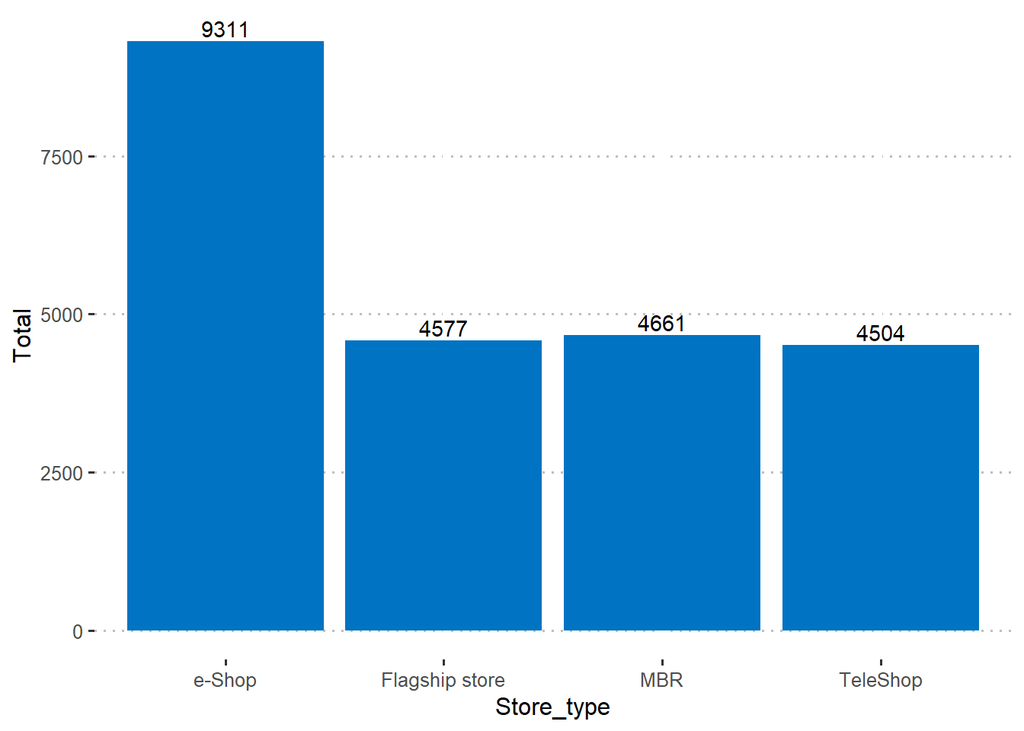

```r
ggplot(Frequency3,aes(x=Store_type,y=Total))+ geom_bar(fill="#0073C2FF",stat = "identity")+geom_text(aes(label=Total),vjust=-0.3)+theme_pubclean()
```

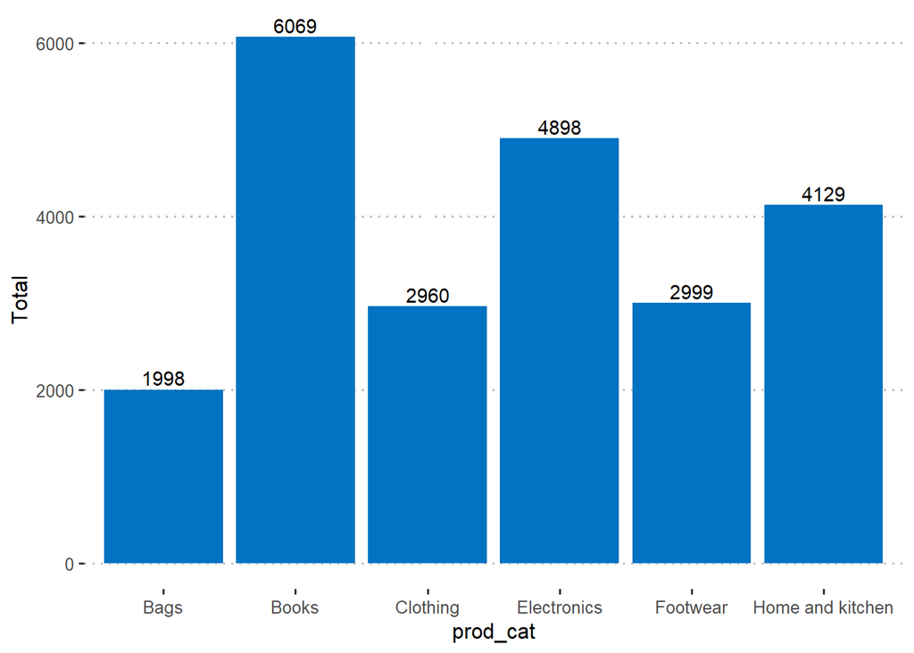

```r
ggplot(Frequency4,aes(x=prod_cat,y=Total))+ geom_bar(fill="#0073C2FF",stat = "identity")+geom_text(aes(label=Total),vjust=-0.3)+theme_pubclean()
```

[figure not shown]

```r
ggplot(Frequency5,aes(x=prod_subcat,y=Total))+ geom_bar(fill="#0073C2FF",stat = "identity")+geom_text(aes(label=Total),vjust=-0.3)+theme_pubclean()
```

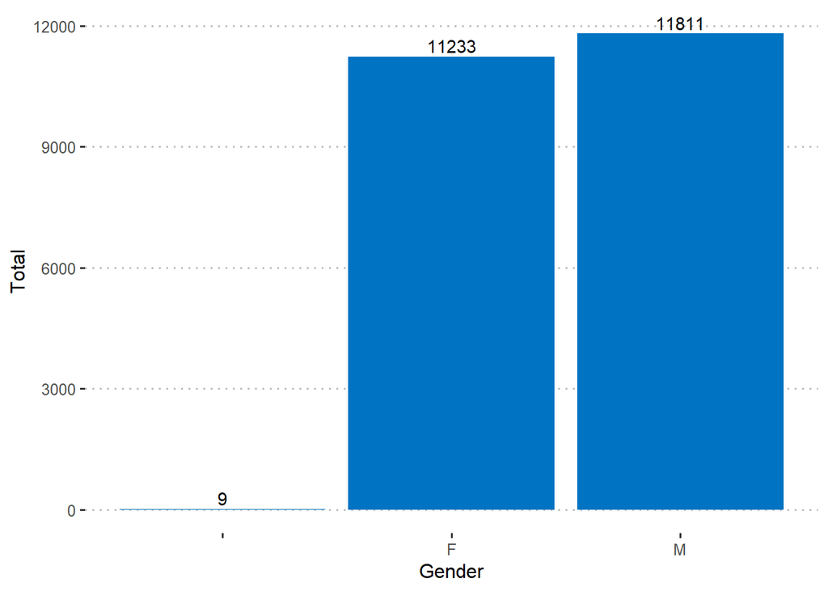

```r
ggplot(Frequency6,aes(x=Gender,y=Total))+ geom_bar(fill="#0073C2FF",stat = "identity")+geom_text(aes(label=Total),vjust=-0.3)+theme_pubclean()
```

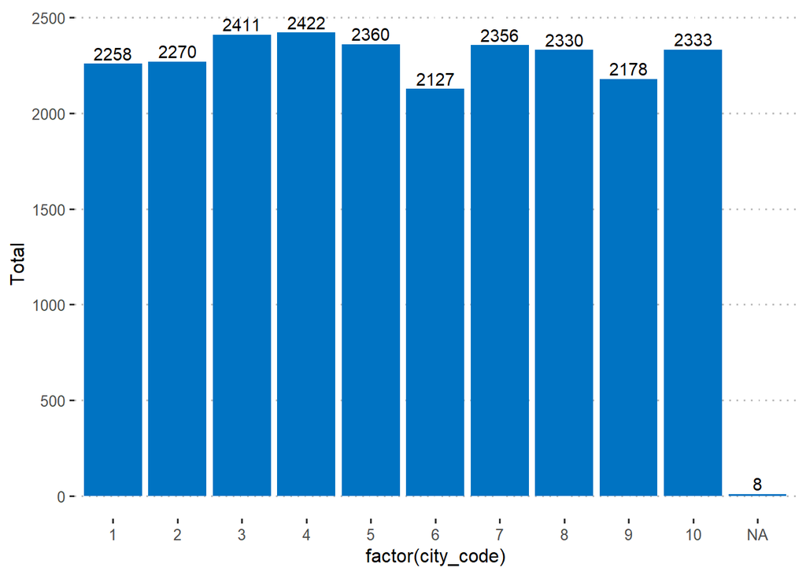

```r
ggplot(Frequency7,aes(x=factor(city_code),y=Total))+ geom_bar(fill="#0073C2FF",stat = "identity")+geom_text(aes(label=Total),vjust=-0.3)+theme_pubclean()
```

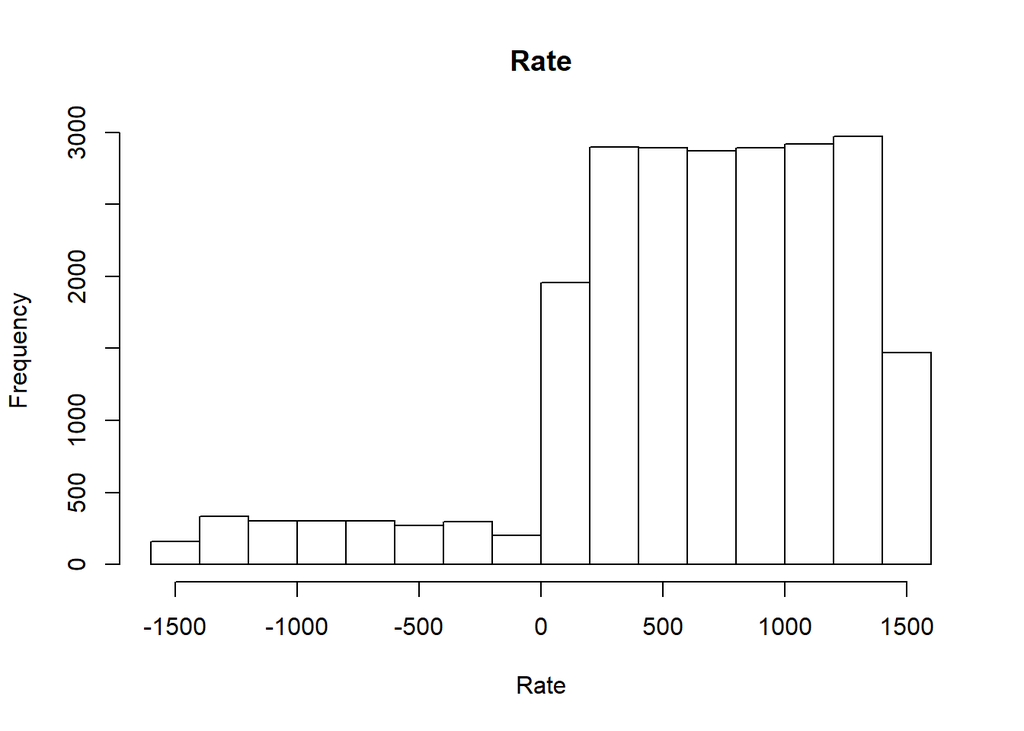

```r
Hist1<-hist(Consumer_Final$Rate, breaks=20, main="Rate",xlab = "Rate")
```

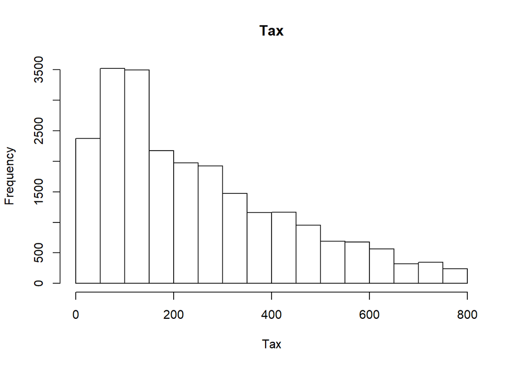

```r
Hist2<-hist(Consumer_Final$Tax, breaks=20, main="Tax",xlab = "Tax")
```

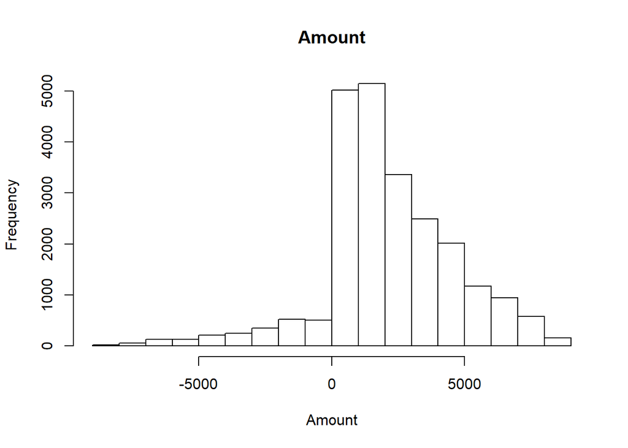

```r
Hist3<-hist(Consumer_Final$total_amt, breaks=20, main="Amount",xlab = "Amount")
```